# ProsperLoan DataExploration

## Introduction

#### Table of Contents:

- Preliminary Wrangling
- Univariate Exploration
  - Numerical Columns
  - Categorical Columns
  - Time Columns
- Bivariate Exploration
- Multivariate Exploration
- Conclusion

> Introduction

variables CurrentlyInGroup, IsBorrowerHomeowner, and IncomeVerifiable are bool variables.

## Preliminary Wrangling

```python
# import all packages and set plots to be embedded inline
import numpy as np
import pandas as pd
import matplotlib.pyplot as plt
import seaborn as sb

%matplotlib inline
```

```python
# load in the dataset into a pandas dataframe, print statistics
prosperloan = pd.read_csv('prosperLoanData.csv')
```

```python
prosperloan.shape
prosperloan.head()
```

|  | ListingKey | ListingNumber | ListingCreationDate | CreditGrade | Term | LoanStatus | ClosedDate | BorrowerAPR | BorrowerRate | LenderYield | ... | LP_ServiceFees | LP_CollectionFees | LP_GrossPrincipalLoss | LP_NetPrincipalLoss | LP_NonPrincipalRecoverypayments | PercentFunded | Recommendations | InvestmentFromFriendsCount | InvestmentFromFriendsAmount | Investors |
| --- | --- | --- | --- | --- | --- | --- | --- | --- | --- | --- | --- | --- | --- | --- | --- | --- | --- | --- | --- | --- | --- |
| 0 | 1021339766868145413AB3B | 193129 | 2007-08-26 19:09:29.263000000 | C | 36 | Completed | 2009-08-14 00:00:00 | 0.16516 | 0.1580 | 0.1380 | ... | -133.18 | 0.0 | 0.0 | 0.0 | 0.0 | 1.0 | 0 | 0 | 0.0 | 258 |
| 1 | 10273602499503308B223C1 | 1209647 | 2014-02-27 08:28:07.900000000 | NaN | 36 | Current | NaN | 0.12016 | 0.0920 | 0.0820 | ... | 0.00 | 0.0 | 0.0 | 0.0 | 0.0 | 1.0 | 0 | 0 | 0.0 | 1 |
| 2 | 0EE9337825851032864889A | 81716 | 2007-01-05 15:00:47.090000000 | HR | 36 | Completed | 2009-12-17 00:00:00 | 0.28269 | 0.2750 | 0.2400 | ... | -24.20 | 0.0 | 0.0 | 0.0 | 0.0 | 1.0 | 0 | 0 | 0.0 | 41 |
| 3 | 0EF5356002482715299901A | 658116 | 2012-10-22 11:02:35.010000000 | NaN | 36 | Current | NaN | 0.12528 | 0.0974 | 0.0874 | ... | -108.01 | 0.0 | 0.0 | 0.0 | 0.0 | 1.0 | 0 | 0 | 0.0 | 158 |
| 4 | 0F023589499656230C5E3E2 | 909464 | 2013-09-14 18:38:39.097000000 | NaN | 36 | Current | NaN | 0.24614 | 0.2085 | 0.1985 | ... | -60.27 | 0.0 | 0.0 | 0.0 | 0.0 | 1.0 | 0 | 0 | 0.0 | 20 |

5 rows × 81 columns

```python
prosperloan.info()
```

```
<class 'pandas.core.frame.DataFrame'>
RangeIndex: 113937 entries, 0 to 113936
Data columns (total 81 columns):
 #   Column                               Non-Null Count   Dtype
---  ------                               --------------   -----
 0   ListingKey                           113937 non-null  object
 1   ListingNumber                        113937 non-null  int64
 2   ListingCreationDate                  113937 non-null  object
 3   CreditGrade                          28953 non-null   object
 4   Term                                 113937 non-null  int64
 5   LoanStatus                           113937 non-null  object
 6   ClosedDate                           55089 non-null   object
 7   BorrowerAPR                          113912 non-null  float64
 8   BorrowerRate                         113937 non-null  float64
 9   LenderYield                          113937 non-null  float64
```

[output cut: 73 more lines]

```python
#Fixing Datatype Issues
prosperloan['ListingCreationDate'] = pd.to_datetime(prosperloan['ListingCreationDate'].astype(str))
prosperloan['ClosedDate'] = pd.to_datetime(prosperloan['ClosedDate'].astype(str))
prosperloan['DateCreditPulled'] = pd.to_datetime(prosperloan['DateCreditPulled'].astype(str))
prosperloan['LoanOriginationDate'] = pd.to_datetime(prosperloan['LoanOriginationDate'].astype(str))

#Adjust datatype for all other categorical columns
prosperloan.Occupation = prosperloan.Occupation.astype('category')
prosperloan.BorrowerState = prosperloan.BorrowerState.astype('category')
prosperloan.LoanStatus = prosperloan.LoanStatus.astype('category')
prosperloan.EmploymentStatus = prosperloan.EmploymentStatus.astype('category')
```

```python
prosperloan.info()
```

```
<class 'pandas.core.frame.DataFrame'>
RangeIndex: 113937 entries, 0 to 113936
Data columns (total 81 columns):
 #   Column                               Non-Null Count   Dtype
---  ------                               --------------   -----
 0   ListingKey                           113937 non-null  object
 1   ListingNumber                        113937 non-null  int64
 2   ListingCreationDate                  113937 non-null  datetime64[ns]
 3   CreditGrade                          28953 non-null   object
 4   Term                                 113937 non-null  int64
 5   LoanStatus                           113937 non-null  category
 6   ClosedDate                           55089 non-null   datetime64[ns]
 7   BorrowerAPR                          113912 non-null  float64
 8   BorrowerRate                         113937 non-null  float64
 9   LenderYield                          113937 non-null  float64
```

[output cut: 73 more lines]

```python
prosperloan.describe().T
```

|  | count | mean | std | min | 25% | 50% | 75% | max |
| --- | --- | --- | --- | --- | --- | --- | --- | --- |
| ListingNumber | 113937.0 | 627885.692506 | 328076.236386 | 4.00000 | 400919.00000 | 600554.00000 | 892634.00000 | 1.255725e+06 |
| Term | 113937.0 | 40.830248 | 10.436212 | 12.00000 | 36.00000 | 36.00000 | 36.00000 | 6.000000e+01 |
| BorrowerAPR | 113912.0 | 0.218828 | 0.080364 | 0.00653 | 0.15629 | 0.20976 | 0.28381 | 5.122900e-01 |
| BorrowerRate | 113937.0 | 0.192764 | 0.074818 | 0.00000 | 0.13400 | 0.18400 | 0.25000 | 4.975000e-01 |
| LenderYield | 113937.0 | 0.182701 | 0.074516 | -0.01000 | 0.12420 | 0.17300 | 0.24000 | 4.925000e-01 |
| ... | ... | ... | ... | ... | ... | ... | ... | ... |
| PercentFunded | 113937.0 | 0.998584 | 0.017919 | 0.70000 | 1.00000 | 1.00000 | 1.00000 | 1.012500e+00 |
| Recommendations | 113937.0 | 0.048027 | 0.332353 | 0.00000 | 0.00000 | 0.00000 | 0.00000 | 3.900000e+01 |
| InvestmentFromFriendsCount | 113937.0 | 0.023460 | 0.232412 | 0.00000 | 0.00000 | 0.00000 | 0.00000 | 3.300000e+01 |
| InvestmentFromFriendsAmount | 113937.0 | 16.550751 | 294.545422 | 0.00000 | 0.00000 | 0.00000 | 0.00000 | 2.500000e+04 |
| Investors | 113937.0 | 80.475228 | 103.239020 | 1.00000 | 2.00000 | 44.00000 | 115.00000 | 1.189000e+03 |

61 rows × 8 columns

```python
prosperloan.duplicated().sum()
```

```
0
```

### What is the structure of your dataset?

> There are 113,937 entries of prosper loan in the dataset with 81 features. Most variables are numeric in nature, but the variables CurrentlyInGroup, IsBorrowerHomeowner, and IncomeVerifiable are bool variables.

The dtypes are: bool(3), category(4), datetime64ns, float64(50), int64(11), object(9)

### What is/are the main feature(s) of interest in your dataset?

> There are some important features to look at including:
- Occupation: The occupation of the borrower at the time they posted the listing.
- EmploymentStatus: The employment status of the borrower at the time they posted the listing.

### What features in the dataset do you think will help support your investigation into your feature(s) of interest?

> Other features which expected to affect the mentioned important features are:
- LoanOriginalAmount: The origination amount of the loan.
- StatedMonthlyIncome: The monthly income the borrower stated at the time the listing was created.
- LoanStatus: The current status of the loan: Cancelled, Chargedoff, Completed, Current, Defaulted, FinalPaymentInProgress, PastDue. The PastDue status will be accompanied by a delinquency bucket.
- ListingCreationDate: The date the listing was created.
- ClosedDate: The date the listing was closed.

## Univariate Exploration

##### Numerical Variables

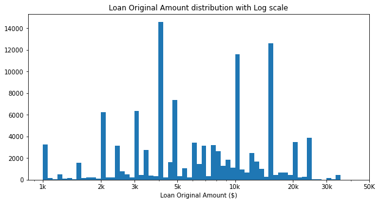

```python
# Loan Original Amount Distribution
# Putting it in a log-scale
log_binsize = 0.025
bins = 10 ** np.arange(3, np.log10(prosperloan['LoanOriginalAmount'].max())+log_binsize, log_binsize)

plt.figure(figsize=[10, 5])
plt.hist(data = prosperloan, x = 'LoanOriginalAmount', bins = bins)
plt.xscale('log')
plt.xticks([1e3, 2e3, 3e3, 5e3, 1e4, 2e4, 3e4, 5e4], ['1k', '2k','3k', '5k', '10k', '20k', '30k', '50K'])
plt.xlabel('Loan Original Amount ($)')
plt.title('Loan Original Amount distribution with Log scale')
plt.show()
```

There is a summit between $4000 and $16000.

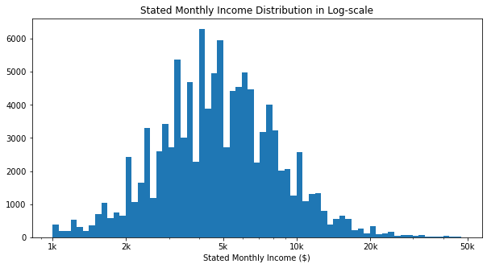

```python
# Using log-scale
#In addition, truncate the X axis to show only values less than 50k which are the majority of data
log_binsize = 0.025
bins = 10 ** np.arange(3, 4.7, log_binsize)

plt.figure(figsize=[10, 5])
plt.hist(data = prosperloan, x = 'StatedMonthlyIncome', bins = bins)
plt.xscale('log')
plt.xticks([1e3, 2e3, 5e3, 1e4, 2e4, 5e4], ['1k', '2k','5k', '10k', '20k', '50k'])
plt.xlabel('Stated Monthly Income ($)')
plt.title('Stated Monthly Income Distribution in Log-scale')
plt.show()
```

There is a peak around $4 k and $5k

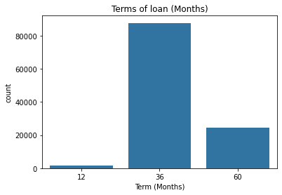

```python
base_color = sb.color_palette()[0]
sb.countplot(data=prosperloan,x= 'Term',color=base_color);
plt.title('Terms of loan (Months)')
plt.xlabel('Term (Months)');
```

This portrays that the term of loan is between 1year to 5years.

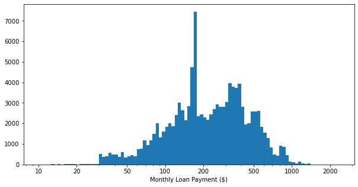

```python
# Using log-scale
log_binsize = 0.025
bins = 10 ** np.arange(1, np.log10(prosperloan['MonthlyLoanPayment'].max())+log_binsize, log_binsize)

plt.figure(figsize=[10, 5])
plt.hist(data = prosperloan, x = 'MonthlyLoanPayment', bins = bins)
plt.xscale('log')
plt.xticks([10, 20, 50, 100, 200, 500, 1e3, 2e3], ['10', '20','50', '100', '200', '500', '1000', '2000'])
plt.xlabel('Monthly Loan Payment ($)')
plt.show()
```

- It is interesting to see the details of the region under 500 and the peak is between 100 and 400

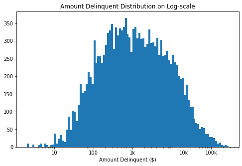

```python
#Amount Delinquent Distribution on a log scale

log_binsize = 0.05
bins = 10 ** np.arange(0.3, 5.5, log_binsize)

plt.figure(figsize=[8, 5])
plt.hist(data = prosperloan, x = 'AmountDelinquent', bins = bins)
plt.xscale('log')
plt.xticks([1e1, 1e2, 1e3, 2e4, 1e5], ['10', '100', '1k', '10k', '100k'])
plt.xlabel('Amount Delinquent ($)')
plt.title('Amount Delinquent Distribution on Log-scale')
plt.show()
```

its abvious that the most amount delinquent is around 400 and 1000

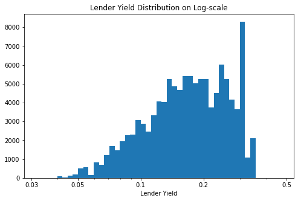

```python
#Lender Yield Distribution with log scale and truncation
log_binsize = 0.025
bins = 10 ** np.arange(-1.5, -0.3, log_binsize)

plt.figure(figsize=[8, 5])
plt.hist(data = prosperloan, x = 'LenderYield', bins = bins)
plt.xscale('log')
plt.xticks([3e-2, 5e-2, 1e-1, 2e-1, 5e-1], ['0.03', '0.05', '0.1', '0.2', '0.5'])
plt.xlabel('Lender Yield')
plt.title('Lender Yield Distribution on Log-scale')

plt.show()
```

> This is negatively skewed

Categorical Variables

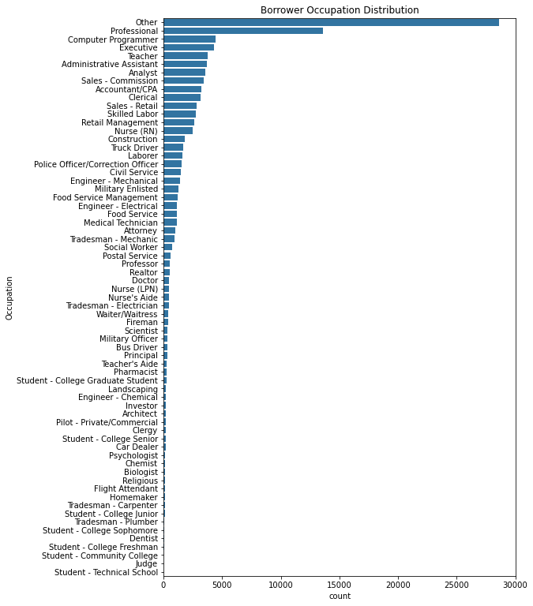

```python
#Borrower Occupation Distrobution
cat_order = prosperloan.Occupation.value_counts().index
plt.figure(figsize=[8, 13])
sb.countplot(data=prosperloan,y='Occupation',color=base_color, order=cat_order);
plt.title('Borrower Occupation Distribution');
```

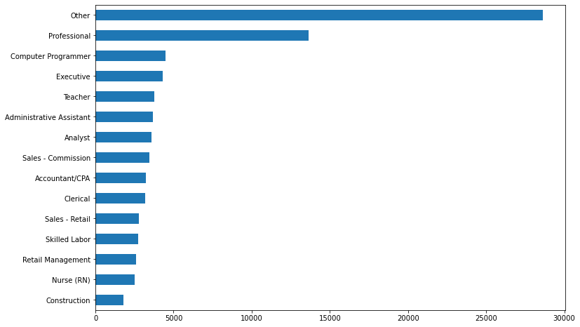

```python
#Top 15 highest occupation
plt.figure(figsize= [12,8])
occupation =prosperloan['Occupation'].value_counts()
ax=occupation.iloc[:15].plot.barh()
ax.invert_yaxis()
ax
```

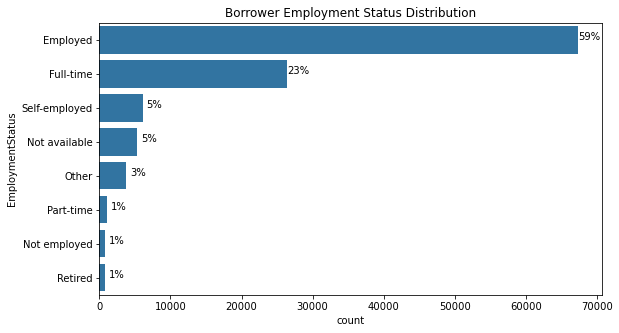

```python
#Borrower Employment Status Distrobution
cat_order = prosperloan.EmploymentStatus.value_counts().index
plt.figure(figsize=[9, 5])
sb.countplot(data=prosperloan,y='EmploymentStatus',color=base_color, order=cat_order);
plt.title('Borrower Employment Status Distribution')

# add annotations
n_points = prosperloan.shape[0]
cat_counts = prosperloan['EmploymentStatus'].value_counts()
locs, labels = plt.yticks() # get the current tick locations and labels

# loop through each pair of locations and labels
for loc, label in zip(locs, labels):

    # get the text property for the label to get the correct count
    count = cat_counts[label.get_text()]
    pct_string = '{:0.0f}%'.format(100*count/n_points)

    # print the annotation just below the top of the bar
    plt.text(count+1600, loc,  pct_string, ha = 'center', color = 'black');
```

- Most loan takers are employed so its safe to say that the chances of loan payoff is feasible.

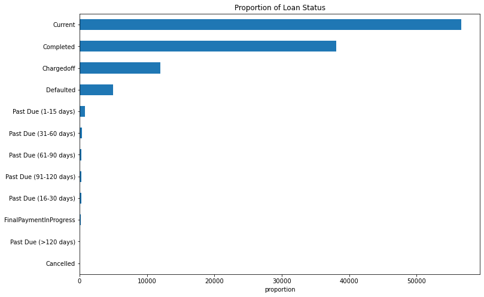

```python
plt.figure(figsize= [12,8])
loanstatus=prosperloan['LoanStatus'].value_counts()
ax=loanstatus.iloc[:15].plot.barh()
ax.invert_yaxis()
plt.xlabel('proportion');
plt.title('Proportion of Loan Status');
```

- Most loan are current and a reasonable amount is completed.

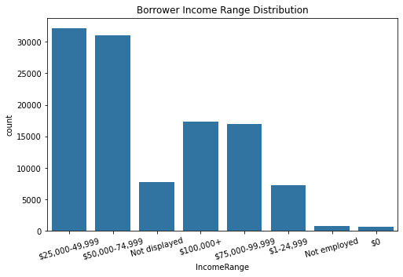

```python
#Borrower Income Range Status Distrobution
plt.figure(figsize=[8, 5])
sb.countplot(data=prosperloan,x='IncomeRange',color=base_color);
plt.title('Borrower Income Range Distribution')
plt.xticks(rotation=15);
```

- It is clear that people with yearly income range of $25,000-49,999 are the most taking loans

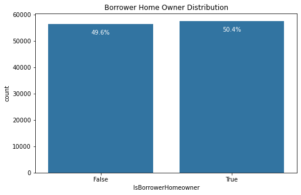

```python
#Is Borrower-Homeowner Status Distribution
plt.figure(figsize=[8, 5])

def str2bool(v):
    return str(v).lower() in ("yes", "true", "True", "1")

base_color = sb.color_palette()[0]
sb.countplot(data = prosperloan, x = 'IsBorrowerHomeowner', color = base_color)

# add annotations
n_points = prosperloan.shape[0]
cat_counts = prosperloan['IsBorrowerHomeowner'].value_counts()
locs, labels = plt.xticks() # get the current tick locations and labels

# loop through each pair of locations and labels
for loc, label in zip(locs, labels):

    # get the text property for the label to get the correct count
    count = cat_counts[str2bool(label.get_text())]
    pct_string = '{:0.1f}%'.format(100*count/n_points)

    # print the annotation just below the top of the bar
    plt.text(loc, count-4000, pct_string, ha = 'center', color = 'w')

plt.title('Borrower Home Owner Distribution');
```

- This depict that owning a home has no effect to taking loans

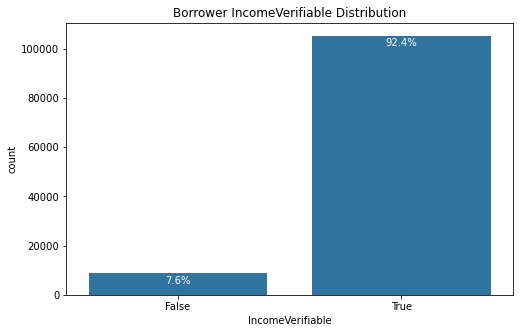

```python
#Is Income-Verifiable Status Distrobution
plt.figure(figsize=[8, 5])

def str2bool(v):
    return str(v).lower() in ("yes", "true", "True", "1")

base_color = sb.color_palette()[0]
sb.countplot(data = prosperloan, x = 'IncomeVerifiable', color = base_color)

# add annotations
n_points = prosperloan.shape[0]
cat_counts = prosperloan['IncomeVerifiable'].value_counts()
locs, labels = plt.xticks() # get the current tick locations and labels

# loop through each pair of locations and labels
for loc, label in zip(locs, labels):

    # get the text property for the label to get the correct count
    count = cat_counts[str2bool(label.get_text())]
    pct_string = '{:0.1f}%'.format(100*count/n_points)

    # print the annotation just below the top of the bar
    plt.text(loc, count-4000, pct_string, ha = 'center', color = 'w')

#sb.countplot(data=prosperloan,x='IsBorrowerHomeowner',color=base_color);
plt.title('Borrower IncomeVerifiable Distribution');
```

- Most borrowers have verified income, which may be a condition for obtaining a loan.

###### Time Variables

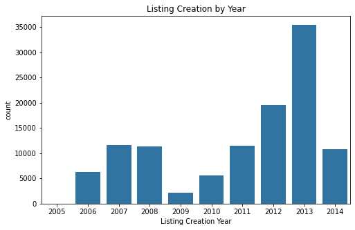

```python
# Listing Creation  by Year
plt.figure(figsize=[8, 5])
sb.countplot(data=prosperloan,x=prosperloan['ListingCreationDate'].dt.year,color=base_color)
plt.title('Listing Creation by Year')
plt.xlabel('Listing Creation Year');
```

- Loan creation fell in 2009 before begining to rebound.

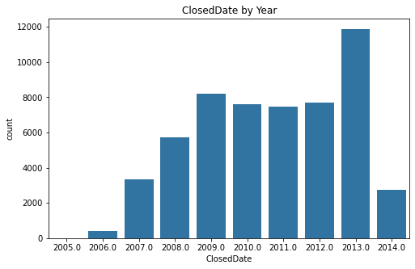

```python
# ClosedDate by Year
plt.figure(figsize=[8, 5])
sb.countplot(data=prosperloan,x=prosperloan['ClosedDate'].dt.year,color=base_color)
plt.title('ClosedDate by Year')
plt.xlabel('ClosedDate');
```

- This shows that most loan was completed on the year 2013

### Of the features you investigated, were there any unusual distributions? Did you perform any operations on the data to tidy, adjust, or change the form of the data? If so, why did you do this?

> Some features had long-tailed, skewed distributions, but i sticked with the log-scale which revealed the hidden distribution in some areas. I did a it bit of wrangling like changing the data types of some variables. Also, after plotting, it was found that some features should be changed to 'Categorical'.

### Bivariate Exploration

> In order to select the proper chart type, we need to identify numeric and categorical features.

```python
#Create lists for numeric and categorical variables
numeric_vars =['Term',  'LenderYield', 'AmountDelinquent', 'StatedMonthlyIncome','LoanCurrentDaysDelinquent',
               'LoanOriginalAmount', 'MonthlyLoanPayment']
categoric_vars = ['LoanStatus', 'Occupation', 'EmploymentStatus']
```

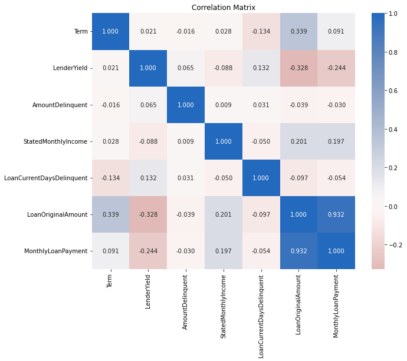

```python
# Correlation matrix for all numeric variables
plt.figure(figsize = [10, 8])
sb.heatmap(prosperloan[numeric_vars].corr(), annot = True, fmt = '.3f',
           cmap = 'vlag_r', center = 0)
plt.title('Correlation Matrix')
plt.margins(x = 0.5, y= 0.3)
plt.show()
```

> LoanOriginalAmount and MonthlyLoanPayment: Strong positive relationship, also makes sense, the bigger the loan the bigger the monthly payments

> The above variables are all dependants on each other

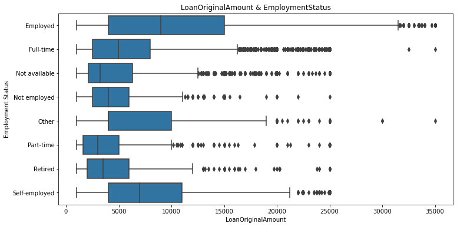

```python
plt.figure(figsize = [12, 6])
sb.boxplot(data=prosperloan,x='LoanOriginalAmount',y='EmploymentStatus',color=base_color);
plt.xlabel('LoanOriginalAmount');
plt.ylabel('Employment Status');
plt.title('LoanOriginalAmount & EmploymentStatus');
```

- Employed people can get larger loan amounts compared to all other categories

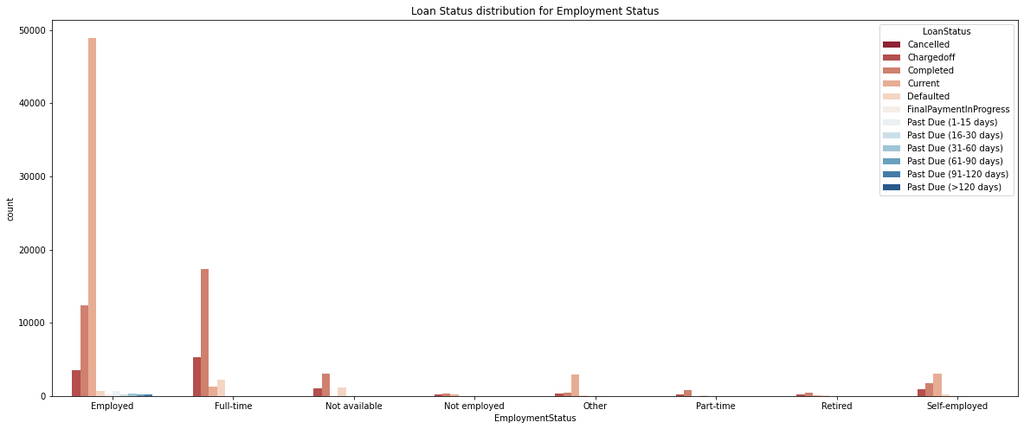

```python
plt.figure(figsize = [20, 8])
sb.countplot(data = prosperloan, x = 'EmploymentStatus', hue = 'LoanStatus', palette='RdBu')
plt.title('Loan Status distribution for Employment Status');
```

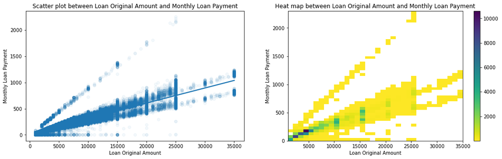

```python
plt.figure(figsize = [18, 5])

plt.subplot(1, 2, 1)
sb.regplot(data=prosperloan,x="LoanOriginalAmount",y="MonthlyLoanPayment",scatter_kws={"alpha":1/20});
plt.xlabel("Loan Original Amount");
plt.ylabel("Monthly Loan Payment");
plt.title("Scatter plot between Loan Original Amount and Monthly Loan Payment");

plt.subplot(1, 2, 2)
x_bin = np.arange(prosperloan['LoanOriginalAmount'].min(), prosperloan['LoanOriginalAmount'].max()+1000,1000)
y_bin = np.arange(prosperloan['MonthlyLoanPayment'].min(), prosperloan['MonthlyLoanPayment'].max()+50, 50)
plt.hist2d(data = prosperloan, x = 'LoanOriginalAmount', y = 'MonthlyLoanPayment', bins = [x_bin, y_bin], cmap = 'viridis_r', cmin = 0.5);
plt.colorbar();
plt.xlabel("Loan Original Amount");
plt.ylabel("Monthly Loan Payment");
plt.title("Heat map between Loan Original Amount and Monthly Loan Payment");
```

- The relation between loan original amount and monthly loan payment is strongly positive in poth heat map and scatter plot

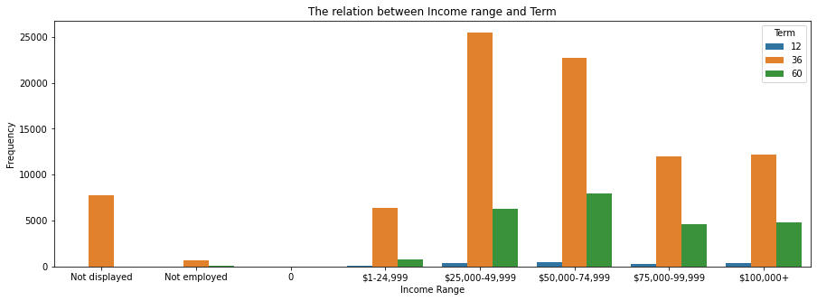

```python
plt.figure(figsize=[15,5])

income_order=["Not displayed","Not employed","0","$1-24,999","$25,000-49,999","$50,000-74,999","$75,000-99,999","$100,000+"]

incoms=pd.api.types.CategoricalDtype(ordered=True,categories=income_order)
prosperloan["IncomeRange"]=prosperloan["IncomeRange"].astype(incoms)

sb.countplot(data=prosperloan,x="IncomeRange",hue="Term");

#labels and title
plt.xlabel("Income Range");
plt.ylabel("Frequency");
plt.title("The relation between Income range and Term");
```

- In all income ranges people prefered to take a loan with 36 months

### Talk about some of the relationships you observed in this part of the investigation. How did the feature(s) of interest vary with other features in the dataset?

> Employed people can get larger loan amounts compared to all other categories

### Did you observe any interesting relationships between the other features (not the main feature(s) of interest)?

> LoanOriginalAmount and MonthlyLoanPayment: Strong positive relationship, also makes sense, the bigger the loan the bigger the monthly payments.

## Multivariate Exploration

> Create plots of three or more variables to investigate your data even further. Make sure that your investigations are justified, and follow from your work in the previous sections.

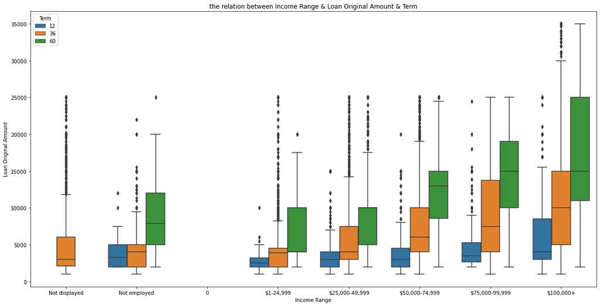

```python
plt.figure(figsize=[20,10])
sb.boxplot(data=prosperloan,x="IncomeRange",y="LoanOriginalAmount",hue="Term");
plt.xlabel("Income Range");
plt.ylabel("Loan Original Amount");
plt.title("the relation between Income Range & Loan Original Amount & Term");
```

- This shows that in each income range the loan original amount icreases the median of 60 months term more than 12 and 36 months term medians

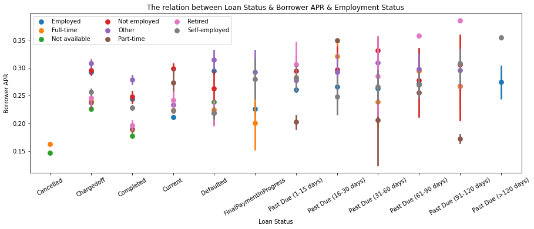

```python
plt.figure(figsize=[15,5])
sb.pointplot(data=prosperloan,x="LoanStatus",y="BorrowerAPR",hue="EmploymentStatus",linestyles="");
plt.xticks(rotation =30);
plt.legend(ncol=3);

plt.ylabel("Borrower APR")
plt.xlabel("Loan Status");
plt.title("The relation between Loan Status & Borrower APR & Employment Status");
```